# Data report overview

The dataset examined has the following dimensions:

| Feature | Result |
| --- | --- |
| Number of observations | 49232 |
| Number of variables | 27 |

# Codebook summary table

| Label | Variable | Class | # unique values | Missing | Description |
| --- | --- | --- | --- | --- | --- |
|  | **cohort** | factor | 2 | 0.00 % |  |
|  | **belong** | numeric | 1564 | 3.24 % |  |
|  | **sex** | factor | 2 | 0.00 % |  |
|  | **indig** | factor | 3 | 0.02 % |  |
|  | **loc** | factor | 3 | 1.11 % |  |
|  | **immig** | factor | 3 | 2.99 % |  |
|  | **egp** | factor | 4 | 12.04 % |  |
|  | **escs** | numeric | 16401 | 2.34 % |  |
|  | **sch_grad1** | numeric | 3 | 42.73 % |  |
|  | **sch_grad2** | numeric | 3 | 46.93 % |  |
|  | **sch_grad3** | numeric | 3 | 50.85 % |  |
|  | **sch_grad4** | numeric | 3 | 59.58 % |  |
|  | **pc1** | numeric | 24901 | 1.11 % |  |
|  | **pc2** | numeric | 24901 | 1.11 % |  |
|  | **pc3** | numeric | 24901 | 1.11 % |  |
|  | **pc4** | numeric | 24900 | 1.11 % |  |
|  | **pc5** | numeric | 24901 | 1.11 % |  |
|  | **neet1** | factor | 3 | 43.93 % |  |
|  | **neet2** | factor | 3 | 46.93 % |  |
|  | **neet3** | factor | 3 | 50.85 % |  |
|  | **neet4** | factor | 3 | 59.58 % |  |
|  | **sch_pc1** | numeric | 1073 | 1.11 % |  |
|  | **sch_pc2** | numeric | 1073 | 1.11 % |  |
|  | **sch_pc3** | numeric | 1073 | 1.11 % |  |
|  | **sch_pc4** | numeric | 1073 | 1.11 % |  |
|  | **sch_pc5** | numeric | 1073 | 1.11 % |  |
|  | **sch_escs** | numeric | 1069 | 1.24 % |  |

# Variable list

## cohort

| Feature | Result |
| --- | --- |
| Variable type | factor |
| Number of missing obs. | 0 (0 %) |
| Number of unique values | 2 |
| Mode | “cohort_2015” |
| Reference category | cohort_2003 |

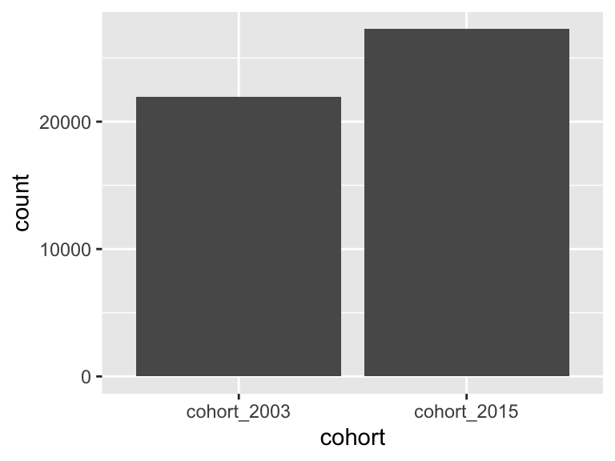

- Observed factor levels: "cohort_2003", "cohort_2015".

## belong

| Feature | Result |
| --- | --- |
| Variable type | numeric |
| Number of missing obs. | 1593 (3.24 %) |
| Number of unique values | 1563 |
| Median | -0.29 |
| 1st and 3rd quartiles | -0.64; 0.49 |
| Min. and max. | -3.38; 2.61 |

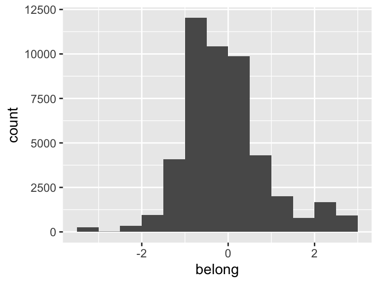

## sex

| Feature | Result |
| --- | --- |
| Variable type | factor |
| Number of missing obs. | 0 (0 %) |
| Number of unique values | 2 |
| Mode | “2” |
| Reference category | 1 |

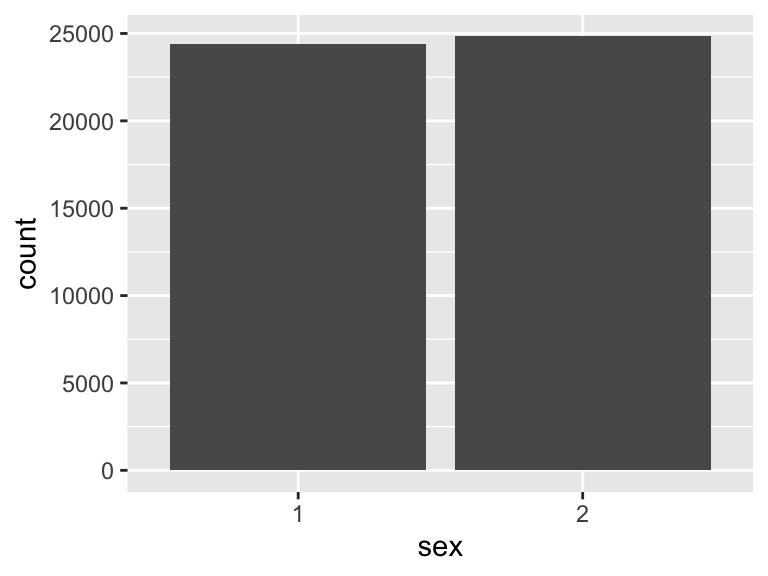

- Observed factor levels: "1", "2".

## indig

| Feature | Result |
| --- | --- |
| Variable type | factor |
| Number of missing obs. | 10 (0.02 %) |
| Number of unique values | 2 |
| Mode | “0” |
| Reference category | 0 |

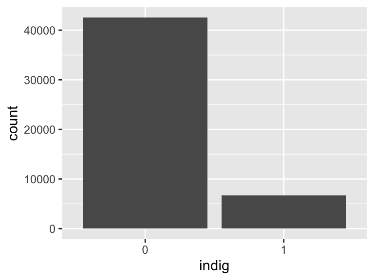

- Observed factor levels: "0", "1".

## loc

| Feature | Result |
| --- | --- |
| Variable type | factor |
| Number of missing obs. | 548 (1.11 %) |
| Number of unique values | 2 |
| Mode | “1” |
| Reference category | 0 |

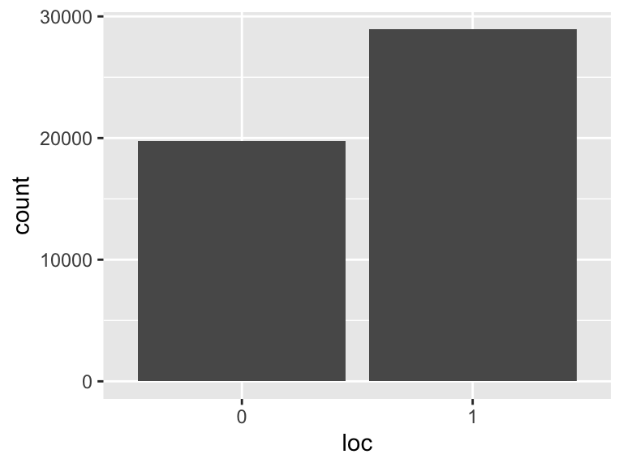

- Observed factor levels: "0", "1".

## immig

| Feature | Result |
| --- | --- |
| Variable type | factor |
| Number of missing obs. | 1473 (2.99 %) |
| Number of unique values | 2 |
| Mode | “0” |
| Reference category | 0 |

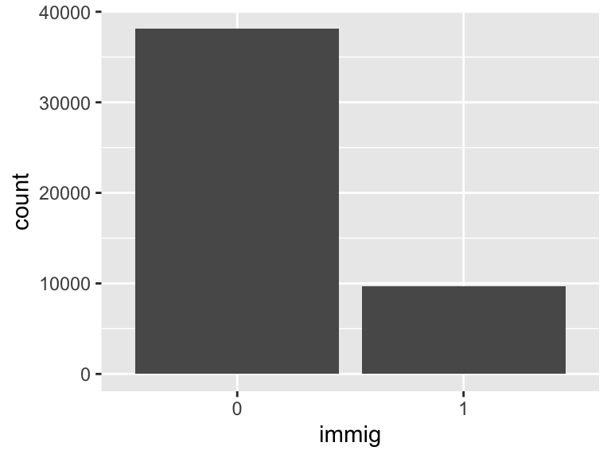

- Observed factor levels: "0", "1".

## egp

| Feature | Result |
| --- | --- |
| Variable type | factor |
| Number of missing obs. | 5928 (12.04 %) |
| Number of unique values | 3 |
| Mode | “salariat” |
| Reference category | intermediate |

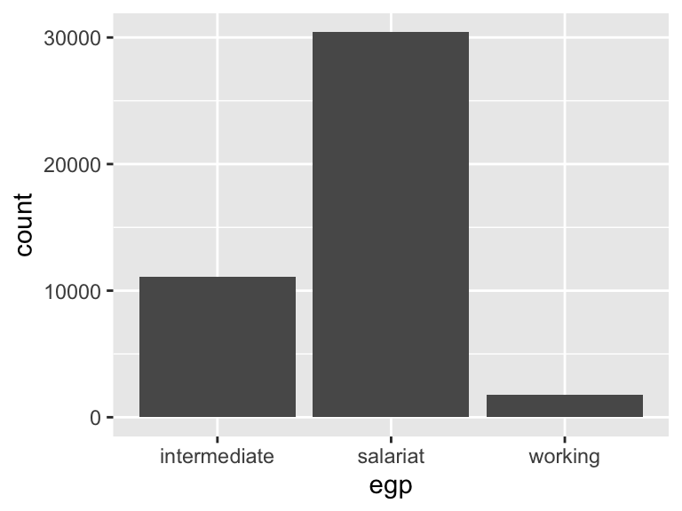

- Observed factor levels: "intermediate", "salariat", "working".

## escs

| Feature | Result |
| --- | --- |
| Variable type | numeric |
| Number of missing obs. | 1153 (2.34 %) |
| Number of unique values | 16400 |
| Median | -0.06 |
| 1st and 3rd quartiles | -0.56; 0.51 |
| Min. and max. | -4.5; 3.18 |

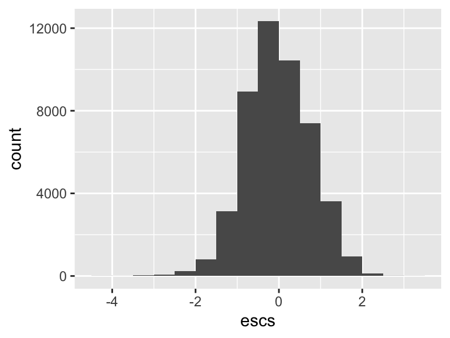

## sch_grad1

| Feature | Result |
| --- | --- |
| Variable type | numeric |
| Number of missing obs. | 21037 (42.73 %) |
| Number of unique values | 2 |
| Median | 0 |
| 1st and 3rd quartiles | 0; 0 |
| Min. and max. | 0; 1 |

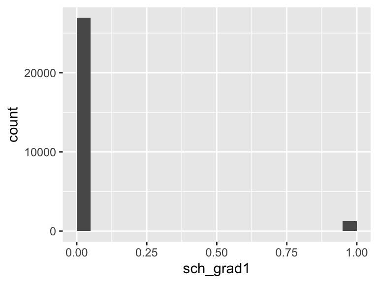

## sch_grad2

| Feature | Result |
| --- | --- |
| Variable type | numeric |
| Number of missing obs. | 23104 (46.93 %) |
| Number of unique values | 2 |
| Median | 0 |
| 1st and 3rd quartiles | 0; 1 |
| Min. and max. | 0; 1 |

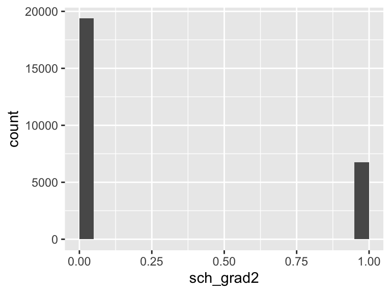

## sch_grad3

| Feature | Result |
| --- | --- |
| Variable type | numeric |
| Number of missing obs. | 25036 (50.85 %) |
| Number of unique values | 2 |
| Median | 1 |
| 1st and 3rd quartiles | 1; 1 |
| Min. and max. | 0; 1 |

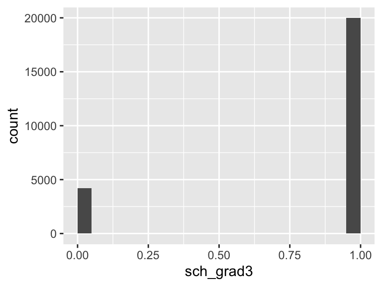

## sch_grad4

| Feature | Result |
| --- | --- |
| Variable type | numeric |
| Number of missing obs. | 29333 (59.58 %) |
| Number of unique values | 2 |
| Median | 1 |
| 1st and 3rd quartiles | 1; 1 |
| Min. and max. | 0; 1 |

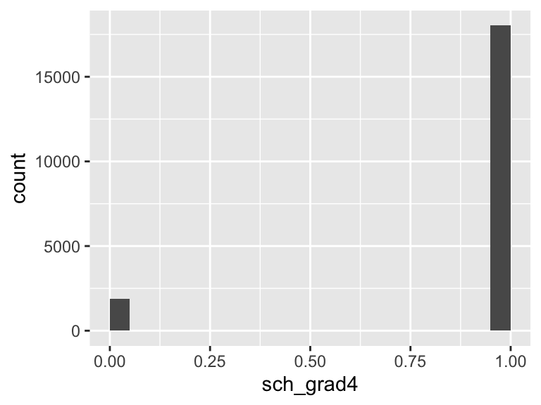

## pc1

| Feature | Result |
| --- | --- |
| Variable type | numeric |
| Number of missing obs. | 548 (1.11 %) |
| Number of unique values | 24900 |
| Median | 0.03 |
| 1st and 3rd quartiles | -0.7; 0.71 |
| Min. and max. | -4.03; 3.49 |

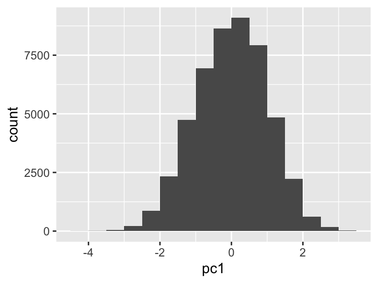

## pc2

| Feature | Result |
| --- | --- |
| Variable type | numeric |
| Number of missing obs. | 548 (1.11 %) |
| Number of unique values | 24900 |
| Median | 0.02 |
| 1st and 3rd quartiles | -0.69; 0.71 |
| Min. and max. | -4.27; 3.58 |

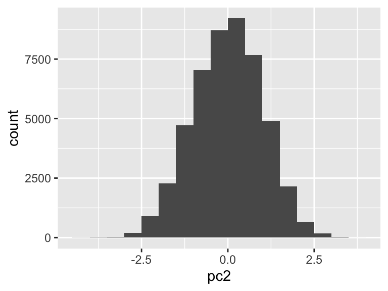

## pc3

| Feature | Result |
| --- | --- |
| Variable type | numeric |
| Number of missing obs. | 548 (1.11 %) |
| Number of unique values | 24900 |
| Median | 0.02 |
| 1st and 3rd quartiles | -0.69; 0.71 |
| Min. and max. | -3.9; 3.71 |

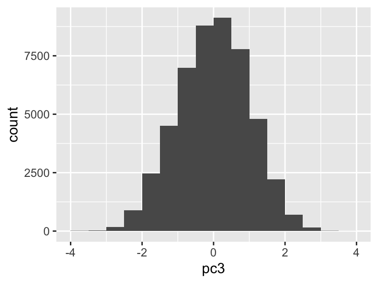

## pc4

| Feature | Result |
| --- | --- |
| Variable type | numeric |
| Number of missing obs. | 548 (1.11 %) |
| Number of unique values | 24899 |
| Median | 0.03 |
| 1st and 3rd quartiles | -0.7; 0.71 |
| Min. and max. | -4.48; 3.64 |

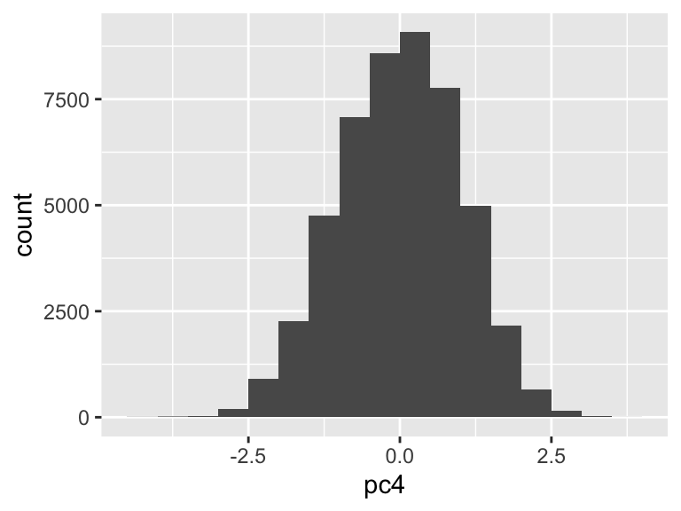

## pc5

| Feature | Result |
| --- | --- |
| Variable type | numeric |
| Number of missing obs. | 548 (1.11 %) |
| Number of unique values | 24900 |
| Median | 0.02 |
| 1st and 3rd quartiles | -0.69; 0.71 |
| Min. and max. | -4.12; 3.56 |

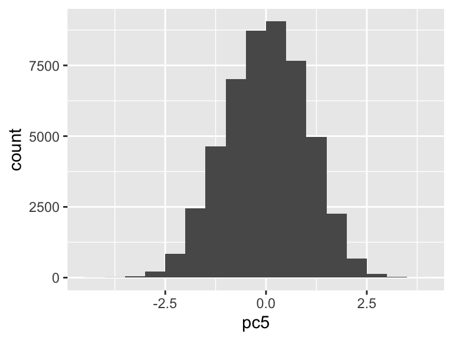

## neet1

| Feature | Result |
| --- | --- |
| Variable type | factor |
| Number of missing obs. | 21626 (43.93 %) |
| Number of unique values | 2 |
| Mode | “0” |
| Reference category | 0 |

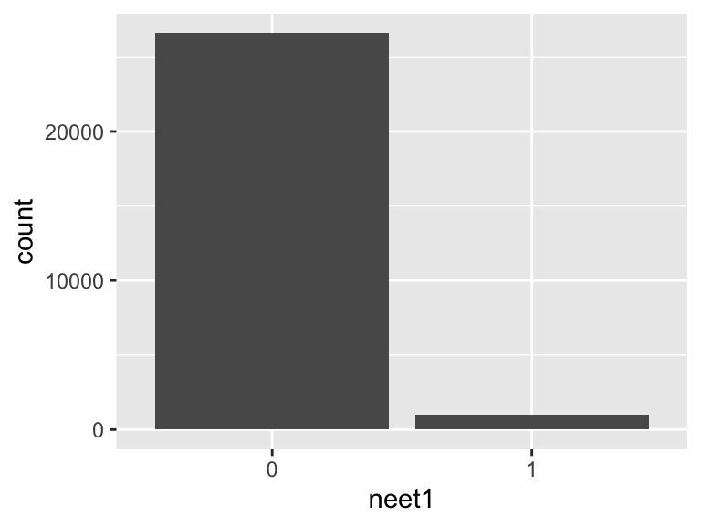

- Observed factor levels: "0", "1".

## neet2

| Feature | Result |
| --- | --- |
| Variable type | factor |
| Number of missing obs. | 23104 (46.93 %) |
| Number of unique values | 2 |
| Mode | “0” |
| Reference category | 0 |

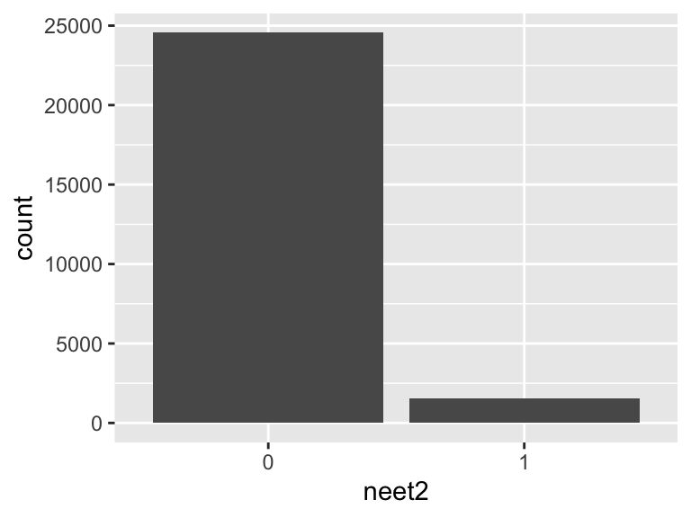

- Observed factor levels: "0", "1".

## neet3

| Feature | Result |
| --- | --- |
| Variable type | factor |
| Number of missing obs. | 25036 (50.85 %) |
| Number of unique values | 2 |
| Mode | “0” |
| Reference category | 0 |

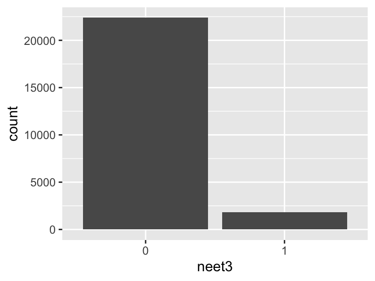

- Observed factor levels: "0", "1".

## neet4

| Feature | Result |
| --- | --- |
| Variable type | factor |
| Number of missing obs. | 29333 (59.58 %) |
| Number of unique values | 2 |
| Mode | “0” |
| Reference category | 0 |

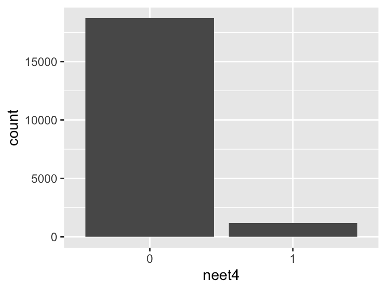

- Observed factor levels: "0", "1".

## sch_pc1

| Feature | Result |
| --- | --- |
| Variable type | numeric |
| Number of missing obs. | 548 (1.11 %) |
| Number of unique values | 1073 |
| Median | -0.03 |
| 1st and 3rd quartiles | -0.36; 0.3 |
| Min. and max. | -2.36; 2.08 |

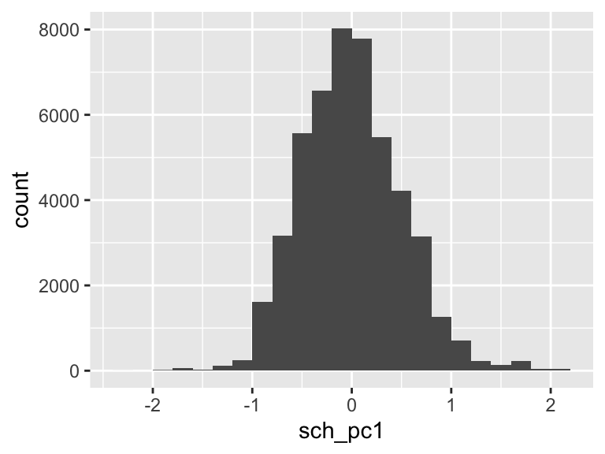

## sch_pc2

| Feature | Result |
| --- | --- |
| Variable type | numeric |
| Number of missing obs. | 548 (1.11 %) |
| Number of unique values | 1073 |
| Median | -0.02 |
| 1st and 3rd quartiles | -0.37; 0.31 |
| Min. and max. | -1.8; 2.25 |

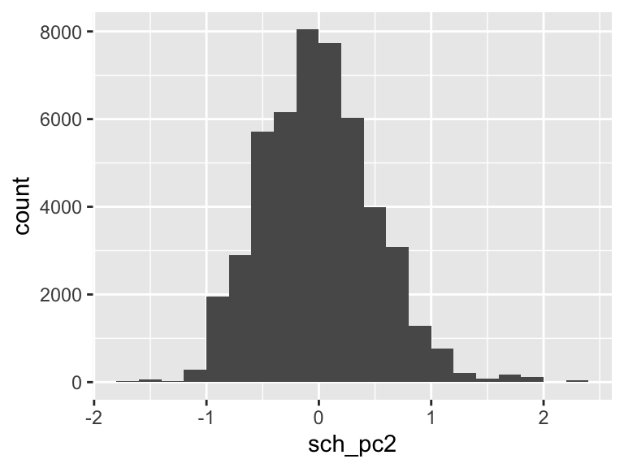

## sch_pc3

| Feature | Result |
| --- | --- |
| Variable type | numeric |
| Number of missing obs. | 548 (1.11 %) |
| Number of unique values | 1073 |
| Median | -0.03 |
| 1st and 3rd quartiles | -0.35; 0.32 |
| Min. and max. | -2.82; 2.04 |

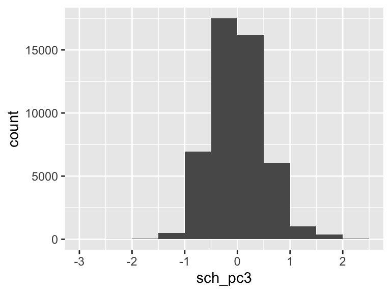

## sch_pc4

| Feature | Result |
| --- | --- |
| Variable type | numeric |
| Number of missing obs. | 548 (1.11 %) |
| Number of unique values | 1073 |
| Median | -0.03 |
| 1st and 3rd quartiles | -0.37; 0.3 |
| Min. and max. | -2.2; 2.15 |

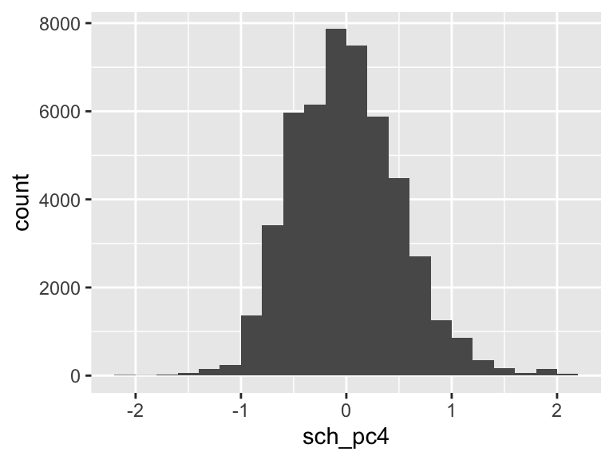

## sch_pc5

| Feature | Result |
| --- | --- |
| Variable type | numeric |
| Number of missing obs. | 548 (1.11 %) |
| Number of unique values | 1073 |
| Median | -0.01 |
| 1st and 3rd quartiles | -0.37; 0.3 |
| Min. and max. | -3.1; 1.98 |

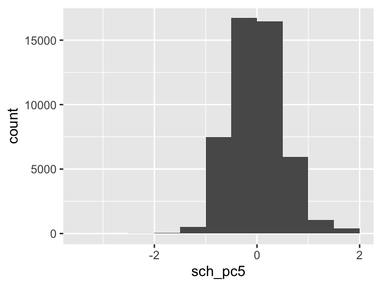

## sch_escs

| Feature | Result |
| --- | --- |
| Variable type | numeric |
| Number of missing obs. | 611 (1.24 %) |
| Number of unique values | 1069 |
| Median | -0.08 |
| 1st and 3rd quartiles | -0.32; 0.22 |
| Min. and max. | -4.06; 1.32 |

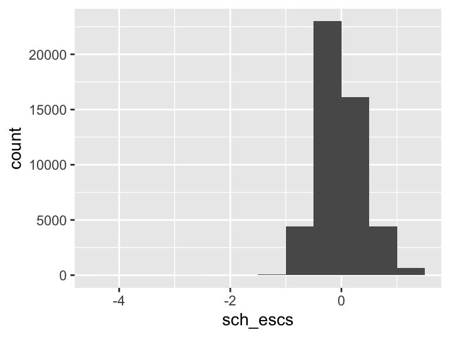

Report generation information:

- Created by: Philip Parker (username: `philipparker`).
- Report creation time: Thu Feb 04 2021 11:52:32
- Report was run from directory: `/Users/philipparker/Dropbox/Projects_Research/CURRENT_WORKING/belonging_NEET`
- dataMaid v1.4.0 [Pkg: 2019-12-10 from CRAN (R 4.0.2)]
- R version 4.0.2 (2020-06-22).
- Platform: x86_64-apple-darwin17.0 (64-bit)(macOS 10.16).
- Function call: `dataMaid::makeDataReport(data = combined_data %>% select(-schid), render = FALSE, mode = c("summarize", "visualize", "check" ), smartNum = FALSE, file = "/Users/philipparker/Dropbox/Projects_Research/CURRENT_WORKING/belonging_NEET/documentation/codebook.pdf", replace = TRUE, standAlone = FALSE, checks = list(character = "showAllFactorLevels", factor = "showAllFactorLevels", labelled = "showAllFactorLevels", haven_labelled = "showAllFactorLevels", numeric = NULL, integer = NULL, logical = NULL, Date = NULL), listChecks = FALSE, maxProbVals = Inf, codebook = TRUE, reportTitle = "Codebook for combined_data %>% select(-schid)")`